# Assignment 5b

- Show All Code
- Hide All Code
- View Source

Author

Anastasiia Gmyrina

## Approach

For this assignment, I will calculate how each player was expected to perform based on their pre-tournament Elo rating and the ratings of their opponents. FFor each game, I will calculate the expected score using the Elo formula:

$$E_A = \frac{1}{1 + 10^{(R_B-R_A)/400}}$$

where $R_A$ is the player’s rating and $R_B$ is the opponent’s rating. I use the expected-score formula described in [How Elo Ratings Actually Work](https://www.chess.com/blog/NateSolon/how-elo-ratings-actually-work) on Chess.com.

I will add the expected scores across all rounds to get each player’s expected tournament score and compare it with the actual points earned. The difference will be used to identify the five players who most overperformed and the five who most underperformed their Elo expectations.

## Data preparation

Since this assignment uses the tournament data from Project 1, i first recreated the player, rating ans opponent data needed for Elo calculations from the original txt file.

```r
library(tidyverse)

# Read original tournament data
chess <- readLines("../project1/tournamentinfo.txt")
chess_data <- chess[-(1:4)]

# Separate player and rating/detail lines
player_info <- chess_data[seq(1, length(chess_data), by = 3)]
details_info <- chess_data[seq(2, length(chess_data), by = 3)]

# Create player data
players <- tibble(player_info = player_info) %>%
  separate_wider_delim(
    player_info,
    delim = "|",
    names = c(
      "player_num", "player_name", "points",
      "round1", "round2", "round3", "round4",
      "round5", "round6", "round7"
    ),
    too_many = "drop"
  )

# Create player rating data
details <- tibble(details_info = details_info) %>%
  separate_wider_delim(
    details_info,
    delim = "|",
    names = c("state", "rating_info"),
    too_many = "drop"
  ) %>%
  mutate(
    pre_rating = as.numeric(
      str_trim(str_extract(rating_info, "(?<=R:)\\s*\\d+"))
    ),
    player_num = row_number()
  ) %>%
  select(player_num, state, pre_rating)

# Create one row for each player-opponent game
opponents <- players %>%
  pivot_longer(
    cols = round1:round7,
    names_to = "round",
    values_to = "result"
  ) %>%
  mutate(
    opponent = as.numeric(str_extract(result, "\\d+"))
  ) %>%
  left_join(
    details,
    by = c("opponent" = "player_num")
  )

head(opponents, 2)
```

| player_num | player_name | points | round | result | opponent | state | pre_rating |
| --- | --- | --- | --- | --- | --- | --- | --- |
| 1 | GARY HUA | 6.0 | round1 | W 39 | 39 | MI | 1436 |
| 1 | GARY HUA | 6.0 | round2 | W 21 | 21 | ON | 1563 |

I will start with the `opponents` data frame created in Project 1. It contains one row for each player-opponent game, along with the opponent’s pre-tournament rating.

For the ELO calculation, I created a new data frame called `elo_data` and kept only the player number and name, opponent number, and opponent rating. I renamed `pre_rating` to `opponent_rating` to make it clear that this rating belongs to the opponent.

```r
elo_data <- opponents %>%
  select(player_num, player_name, opponent, pre_rating) %>%
  rename(opponent_rating = pre_rating)
head(elo_data, 2)
```

| player_num | player_name | opponent | opponent_rating |
| --- | --- | --- | --- |
| 1 | GARY HUA | 39 | 1436 |
| 1 | GARY HUA | 21 | 1563 |

The ELO formula requires both the player’s rating and the opponent’s rating. The `details` data frame from Project 1 contains each player’s pre-tournament rating. Before joining the data, I converted `player_num` to numeric so it matches the data type in `details`. I then joined the player’s rating using `player_num` and renamed it `player_rating`.

```r
elo_data <- elo_data %>%
  mutate(player_num = as.numeric(player_num)) %>%
  left_join(
    details %>%
      select(player_num, pre_rating) %>%
      rename(player_rating = pre_rating),
    by = "player_num")

head(elo_data, 2)
```

| player_num | player_name | opponent | opponent_rating | player_rating |
| --- | --- | --- | --- | --- |
| 1 | GARY HUA | 39 | 1436 | 1794 |
| 1 | GARY HUA | 21 | 1563 | 1794 |

## Elo Expected Score

Now I have both ratings, so I can calculate the expected score for each game. I used the ELO expected-score formula, which estimates the expected result based on the difference between the two players’ ratings. I used `mutate()` to apply the formula to every game and rounded the result to three decimal places.

```r
elo_data <- elo_data %>%
  mutate(expected_score = round(1 / (1 + 10^((opponent_rating - player_rating) / 400)),3))

head(elo_data, 7)
```

| player_num | player_name | opponent | opponent_rating | player_rating | expected_score |
| --- | --- | --- | --- | --- | --- |
| 1 | GARY HUA | 39 | 1436 | 1794 | 0.887 |
| 1 | GARY HUA | 21 | 1563 | 1794 | 0.791 |
| 1 | GARY HUA | 18 | 1600 | 1794 | 0.753 |
| 1 | GARY HUA | 14 | 1610 | 1794 | 0.743 |
| 1 | GARY HUA | 7 | 1649 | 1794 | 0.697 |
| 1 | GARY HUA | 12 | 1663 | 1794 | 0.680 |
| 1 | GARY HUA | 4 | 1716 | 1794 | 0.610 |

## Tournament Results

Each row currently contains the expected score for one game. To calculate each player’s expected score for the entire tournament, I grouped the data by player and added their expected scores across all games.

```r
elo_summary <- elo_data %>%
  group_by(player_num, player_name) %>%
  summarise(
    expected_score = round(sum(expected_score, na.rm = TRUE), 2),
    .groups = "drop"
  )

head(elo_summary)
```

| player_num | player_name | expected_score |
| --- | --- | --- |
| 1 | GARY HUA | 5.16 |
| 2 | DAKSHESH DARURI | 3.78 |
| 3 | ADITYA BAJAJ | 1.95 |
| 4 | PATRICK H SCHILLING | 4.74 |
| 5 | HANSHI ZUO | 4.38 |
| 6 | HANSEN SONG | 4.95 |

```r
elo_summary <- elo_summary %>%
  left_join(
    players %>%
      select(player_name, points),
    by = "player_name"
  ) %>%
  mutate(
    points = as.numeric(points),
    difference = round(points - expected_score, 2)
  )

head(elo_summary)
```

| player_num | player_name | expected_score | points | difference |
| --- | --- | --- | --- | --- |
| 1 | GARY HUA | 5.16 | 6.0 | 0.84 |
| 2 | DAKSHESH DARURI | 3.78 | 6.0 | 2.22 |
| 3 | ADITYA BAJAJ | 1.95 | 6.0 | 4.05 |
| 4 | PATRICK H SCHILLING | 4.74 | 5.5 | 0.76 |
| 5 | HANSHI ZUO | 4.38 | 5.5 | 1.12 |
| 6 | HANSEN SONG | 4.95 | 5.0 | 0.05 |

## Top Overperformers and Underperformers

I sorted the players by the difference between their actual and expected scores. The five largest positive differences represent the players who most overperformed relative to their expected score, while the five lowest differences represent the players who most underperformed.

```r
top_overperformers <- elo_summary %>%
  arrange(desc(difference)) %>%
  slice_head(n = 5)

top_overperformers
```

| player_num | player_name | expected_score | points | difference |
| --- | --- | --- | --- | --- |
| 3 | ADITYA BAJAJ | 1.95 | 6.0 | 4.05 |
| 15 | ZACHARY JAMES HOUGHTON | 1.37 | 4.5 | 3.13 |
| 10 | ANVIT RAO | 1.94 | 5.0 | 3.06 |
| 46 | JACOB ALEXANDER LAVALLEY | 0.04 | 3.0 | 2.96 |
| 37 | AMIYATOSH PWNANANDAM | 0.77 | 3.5 | 2.73 |

```r
top_underperformers <- elo_summary %>%
  arrange(difference) %>%
  slice_head(n = 5)

top_underperformers
```

| player_num | player_name | expected_score | points | difference |
| --- | --- | --- | --- | --- |
| 25 | LOREN SCHWIEBERT | 6.28 | 3.5 | -2.78 |
| 30 | GEORGE AVERY JONES | 6.02 | 3.5 | -2.52 |
| 42 | JARED GE | 5.01 | 3.0 | -2.01 |
| 31 | RISHI SHETTY | 5.09 | 3.5 | -1.59 |
| 35 | JOSHUA DAVID LEE | 4.96 | 3.5 | -1.46 |

The results show a wide range of performance relative to Elo expectations. Aditya Bajaj had the largest overperformance, scoring 6.0 points compared with an expected score of 1.95, a difference of +4.05. On the other side, Loren Schwiebert had the largest underperformance, scoring 3.5 points compared with an expected 6.28, a difference of -2.78. This shows that actual tournament performance can differ substantially from what the players’ pre-tournament ratings would predict.

## Performance Visualization

To make the differences easier to compare, I combined the five largest overperformers and underperformers in one chart. The center line represents performance exactly as expected based on ELO ratings. Positive values show players who scored above expectations, while negative values show players who scored below expectations.

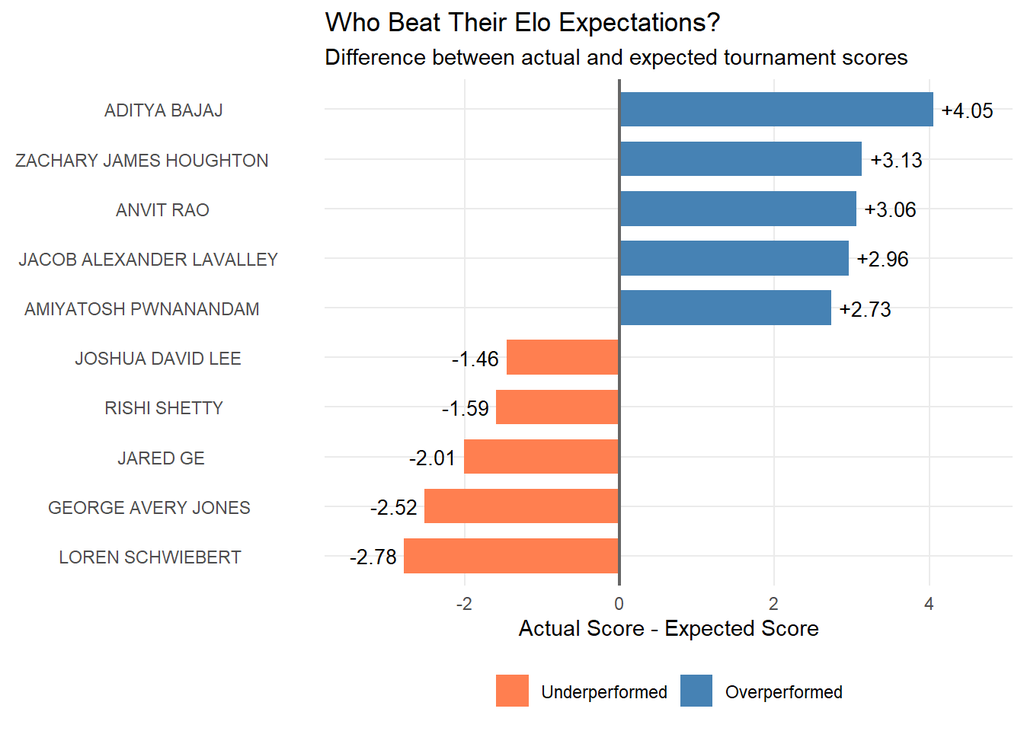

```r
performance_plot <- bind_rows(
  top_overperformers,
  top_underperformers
)

ggplot(performance_plot,aes(x = difference, y = reorder(player_name, difference),
    fill = difference > 0)) +
  geom_col(width = 0.7) +
  geom_vline(xintercept = 0, color = "grey40",linewidth = 0.8) +
  geom_text(
    aes(
      label = ifelse(
        difference > 0,
        paste0("+", difference),
        difference
      ),
      hjust = ifelse(difference > 0, -0.15, 1.15)
    ),
    size = 3.5
  ) +
  scale_fill_manual(
    values = c("TRUE" = "steelblue","FALSE" = "coral"),
    labels = c("TRUE" = "Overperformed","FALSE" = "Underperformed")) +
  scale_x_continuous(expand = expansion(mult = c(0.15, 0.15))) +
  labs(
    title = "Who Beat Their Elo Expectations?",
    subtitle = "Difference between actual and expected tournament scores",
    x = "Actual Score - Expected Score",
    y = NULL,
    fill = NULL
  ) +
  theme_minimal() +
  theme(legend.position = "bottom", panel.grid.minor = element_blank())
```

## Summary

Using the players’ pre-tournament Elo ratings, I calculated an expected score for each game and added these values to get each player’s expected tournament score. The comparison with actual results showed some large differences. Aditya Bajaj had the largest overperformance, scoring 4.05 points above expectation, while Loren Schwiebert had the largest underperformance, scoring 2.78 points below expectation.

The results show that Elo ratings can be useful for estimating expected performance, but actual tournament results can differ quite a bit